# “Identification of high-risk COVID-19 patients using machine learning”

#### Introduction to Data Science

#### Faculdade de Ciências da Universidade do Porto

##### December 2022 - intermediate submission

Group E:  
Francisco Rolo (up202203838)  
José Eduardo Pereira (up202204480)  
Nuno Fernandes (up202109069)

## 1 - Business understanding

### Determine Business Objectives

##### Background:

COVID-19 pandemic introduces great distress in the world by impacting severely all healthcare systems and the way social interactions are made, due to being a highly contagious disease. Leading to profound economic disruptions in people's normal way of life.

##### Business Objectives:

Understand how the disease impacts individuals given certain characteristics in order to improve hospital capacity planning and timely treatment.

##### Business Success Criteria:

Identify high-risk patients with high accuracy.

##### Machine Learning Problem:

Create a model that can classify an individual as a high-risk or low-risk given the impact of the disease in previous patients.

##### Machine Learning Success Criteria:

Correctly classifying the patients.

### Assess Situation

##### Inventory of Resources:

```
- 3 students from introduction to data science course
- a database of confirmed and suspected COVID-19 infections in Mexico
- jupyter notebook
```

##### Requirements, Assumptions & Constraints:

```
- final deadline is January 12th 2023
- 5 minutes presentation in the class of 16th of December
- intermediate submission on December 16: html version of the notebook with the first 2 CRISP-DM phases and part of the 3rd
- we assume data is complete, reliable and understandable
```

##### Risks and Contingencies

Non-Applicable due to being a school project

##### Costs and Benefits

Non-Applicable due to being a school project

## 2 - Data Understanding

### Collect Initial Data

```python
import pandas as pd
import numpy as np
import matplotlib.pyplot as plt
import seaborn as sns

from sklearn.preprocessing import LabelEncoder
from sklearn.model_selection import train_test_split
from sklearn.linear_model import LogisticRegression
from sklearn.metrics import DetCurveDisplay, RocCurveDisplay
from sklearn import metrics
from sklearn.pipeline import make_pipeline
from sklearn.preprocessing import StandardScaler
from sklearn.metrics import confusion_matrix
from sklearn.decomposition import PCA
```

```python
df = pd.read_csv("covid19Mexico_Apr2020_Jan2021.csv")
df.head()
```

|  | FECHA_ACTUALIZACION | ID_REGISTRO | ORIGEN | SECTOR | ENTIDAD_UM | SEXO | ENTIDAD_NAC | ENTIDAD_RES | MUNICIPIO_RES | TIPO_PACIENTE | ... | OTRO_CASO | TOMA_MUESTRA_LAB | RESULTADO_LAB | TOMA_MUESTRA_ANTIGENO | RESULTADO_ANTIGENO | CLASIFICACION_FINAL | MIGRANTE | PAIS_NACIONALIDAD | PAIS_ORIGEN | UCI |
| --- | --- | --- | --- | --- | --- | --- | --- | --- | --- | --- | --- | --- | --- | --- | --- | --- | --- | --- | --- | --- | --- |
| 1 | 2021-10-31 | z4d6fe | 1 | 6 | 24 | 1 | 24 | 24 | 28 | 1 | ... | 2 | 1 | 1 | 2 | 97 | 3 | 99 | México | 97 | 97 |
| 2 | 2021-10-31 | z1e370 | 1 | 12 | 14 | 1 | 14 | 14 | 85 | 1 | ... | 2 | 1 | 2 | 2 | 97 | 7 | 99 | México | 97 | 97 |
| 3 | 2021-10-31 | z3bf80 | 2 | 12 | 8 | 2 | 8 | 8 | 37 | 1 | ... | 2 | 1 | 1 | 2 | 97 | 3 | 99 | México | 97 | 97 |
| 4 | 2021-10-31 | zz7067 | 1 | 12 | 9 | 2 | 9 | 9 | 7 | 1 | ... | 2 | 1 | 2 | 2 | 97 | 7 | 99 | México | 97 | 97 |
| 5 | 2021-10-31 | z393a3 | 1 | 12 | 9 | 1 | 9 | 9 | 17 | 1 | ... | 1 | 2 | 97 | 1 | 2 | 7 | 99 | México | 97 | 97 |

5 rows × 40 columns

### Describe Data

```python
print("The dataset has",df.shape[0],"cases and",df.shape[1],"features")
```

```
The dataset has 3779640 cases and 40 features
```

```python
df.describe(include = "all")
```

|  | FECHA_ACTUALIZACION | ID_REGISTRO | ORIGEN | SECTOR | ENTIDAD_UM | SEXO | ENTIDAD_NAC | ENTIDAD_RES | MUNICIPIO_RES | TIPO_PACIENTE | ... | OTRO_CASO | TOMA_MUESTRA_LAB | RESULTADO_LAB | TOMA_MUESTRA_ANTIGENO | RESULTADO_ANTIGENO | CLASIFICACION_FINAL | MIGRANTE | PAIS_NACIONALIDAD | PAIS_ORIGEN | UCI |
| --- | --- | --- | --- | --- | --- | --- | --- | --- | --- | --- | --- | --- | --- | --- | --- | --- | --- | --- | --- | --- | --- |
| count | 3779640 | 3779640 | 3.779640e+06 | 3.779640e+06 | 3.779640e+06 | 3.779640e+06 | 3.779640e+06 | 3.779640e+06 | 3.779640e+06 | 3.779640e+06 | ... | 3.779640e+06 | 3.779640e+06 | 3.779640e+06 | 3.779640e+06 | 3.779640e+06 | 3.779640e+06 | 3.779640e+06 | 3779640 | 3779640 | 3.779640e+06 |
| unique | 1 | 3779640 | NaN | NaN | NaN | NaN | NaN | NaN | NaN | NaN | ... | NaN | NaN | NaN | NaN | NaN | NaN | NaN | 141 | 98 | NaN |
| top | 2021-10-31 | z4d6fe | NaN | NaN | NaN | NaN | NaN | NaN | NaN | NaN | ... | NaN | NaN | NaN | NaN | NaN | NaN | NaN | México | 97 | NaN |
| freq | 3779640 | 1 | NaN | NaN | NaN | NaN | NaN | NaN | NaN | NaN | ... | NaN | NaN | NaN | NaN | NaN | NaN | NaN | 3762115 | 3775711 | NaN |
| mean | NaN | NaN | 1.685989e+00 | 9.511909e+00 | 1.428661e+01 | 1.482816e+00 | 1.534563e+01 | 1.460025e+01 | 3.280078e+01 | 1.134076e+00 | ... | 7.144544e+00 | 1.194510e+00 | 2.018786e+01 | 1.857466e+00 | 8.342433e+01 | 5.214347e+00 | 9.858829e+01 | NaN | NaN | 8.440773e+01 |
| std | NaN | NaN | 4.641209e-01 | 3.569800e+00 | 7.888192e+00 | 4.997047e-01 | 9.693700e+00 | 7.820309e+00 | 4.431819e+01 | 3.407337e-01 | ... | 2.275771e+01 | 3.958229e-01 | 3.775104e+01 | 3.495975e-01 | 3.329775e+01 | 1.986074e+00 | 6.314146e+00 | NaN | NaN | 3.223429e+01 |
| min | NaN | NaN | 1.000000e+00 | 1.000000e+00 | 1.000000e+00 | 1.000000e+00 | 1.000000e+00 | 1.000000e+00 | 1.000000e+00 | 1.000000e+00 | ... | 1.000000e+00 | 1.000000e+00 | 1.000000e+00 | 1.000000e+00 | 1.000000e+00 | 1.000000e+00 | 1.000000e+00 | NaN | NaN | 1.000000e+00 |
| 25% | NaN | NaN | 1.000000e+00 | 4.000000e+00 | 9.000000e+00 | 1.000000e+00 | 9.000000e+00 | 9.000000e+00 | 7.000000e+00 | 1.000000e+00 | ... | 1.000000e+00 | 1.000000e+00 | 1.000000e+00 | 2.000000e+00 | 9.700000e+01 | 3.000000e+00 | 9.900000e+01 | NaN | NaN | 9.700000e+01 |
| 50% | NaN | NaN | 2.000000e+00 | 1.200000e+01 | 1.100000e+01 | 1.000000e+00 | 1.300000e+01 | 1.300000e+01 | 1.700000e+01 | 1.000000e+00 | ... | 2.000000e+00 | 1.000000e+00 | 2.000000e+00 | 2.000000e+00 | 9.700000e+01 | 7.000000e+00 | 9.900000e+01 | NaN | NaN | 9.700000e+01 |
| 75% | NaN | NaN | 2.000000e+00 | 1.200000e+01 | 2.000000e+01 | 2.000000e+00 | 2.100000e+01 | 2.000000e+01 | 3.900000e+01 | 1.000000e+00 | ... | 2.000000e+00 | 1.000000e+00 | 2.000000e+00 | 2.000000e+00 | 9.700000e+01 | 7.000000e+00 | 9.900000e+01 | NaN | NaN | 9.700000e+01 |
| max | NaN | NaN | 2.000000e+00 | 9.900000e+01 | 3.200000e+01 | 2.000000e+00 | 9.900000e+01 | 3.200000e+01 | 9.990000e+02 | 2.000000e+00 | ... | 9.900000e+01 | 2.000000e+00 | 9.700000e+01 | 2.000000e+00 | 9.700000e+01 | 7.000000e+00 | 9.900000e+01 | NaN | NaN | 9.900000e+01 |

11 rows × 40 columns

```python
df.info(show_counts=True)
```

```
<class 'pandas.core.frame.DataFrame'>
Int64Index: 3779640 entries, 1 to 3779640
Data columns (total 40 columns):
 #   Column                 Non-Null Count    Dtype
---  ------                 --------------    -----
 0   FECHA_ACTUALIZACION    3779640 non-null  object
 1   ID_REGISTRO            3779640 non-null  object
 2   ORIGEN                 3779640 non-null  int64
 3   SECTOR                 3779640 non-null  int64
 4   ENTIDAD_UM             3779640 non-null  int64
 5   SEXO                   3779640 non-null  int64
 6   ENTIDAD_NAC            3779640 non-null  int64
 7   ENTIDAD_RES            3779640 non-null  int64
 8   MUNICIPIO_RES          3779640 non-null  int64
 9   TIPO_PACIENTE          3779640 non-null  int64
```

[output cut: 32 more lines]

From the 40 features, 33 are numerical and 7 are nominal.  
All cases have values for all features and therefore all the features have the same 3.779.640 cases.

Additional catalogues are provided by the Mexican Authorities with the features' description and the different possibilities that each one of the features can assume. In some cases, the missing values were previously replaced by numerical entries like 97, 98, 99, 997, 998, 999.

### Explore Data

```python
# understanding evolution over time

df["FECHA_DEF"].replace({"9999-99-99": pd.NA}, inplace=True)
df['FECHA_INGRESO'] = pd.to_datetime(df['FECHA_INGRESO'],format="%Y/%m/%d")
df['FECHA_SINTOMAS'] = pd.to_datetime(df['FECHA_SINTOMAS'],format="%Y/%m/%d")
df['FECHA_DEF'] = pd.to_datetime(df['FECHA_DEF'],format="%Y/%m/%d")
fi = pd.DataFrame(df["FECHA_INGRESO"].value_counts())
fs = pd.DataFrame(df["FECHA_SINTOMAS"].value_counts())
fd = pd.DataFrame(df["FECHA_DEF"].value_counts())
fechas = pd.concat([fi,fs,fd], axis=1)
fechas.reset_index(inplace=True)
```

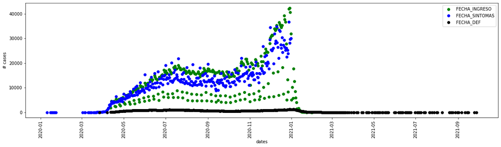

```python
# plot scatter
plt.figure(figsize=(20,5))
plt.scatter(fechas['index'], fechas['FECHA_INGRESO'], label = "FECHA_INGRESO", color='green')
plt.scatter(fechas['index'], fechas['FECHA_SINTOMAS'], label = "FECHA_SINTOMAS", color='blue')
plt.scatter(fechas['index'], fechas['FECHA_DEF'], label = "FECHA_DEF", color='black')
plt.legend()
plt.xlabel('dates')
plt.xticks(rotation=90)
plt.ylabel('# cases')
plt.show()
```

```python
tipo_1 = len(df[(df['TIPO_PACIENTE']==1)])
tipo_2 = len(df[(df['TIPO_PACIENTE']==2)])
```

```python
print("number of positive outcomes:", tipo_1)
print("number of worst outcomes:", tipo_2)
```

```
number of positive outcomes: 3272882
number of worst outcomes: 506758
```

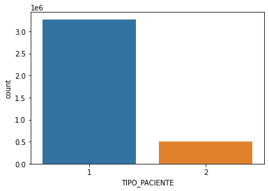

```python
sns.countplot(data=df, x="TIPO_PACIENTE")
```

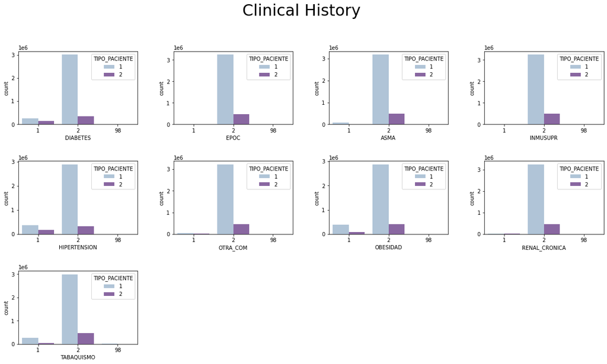

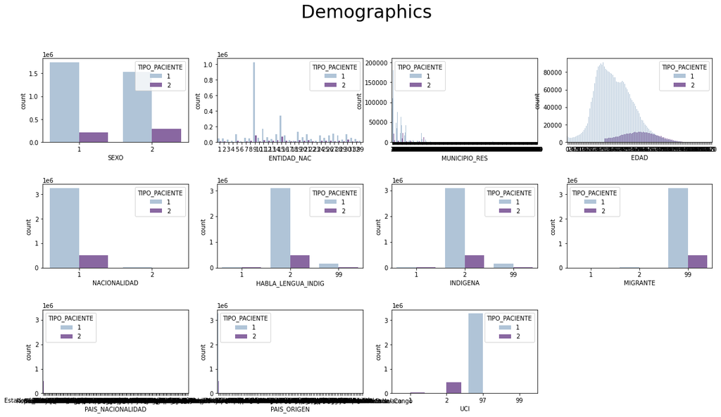

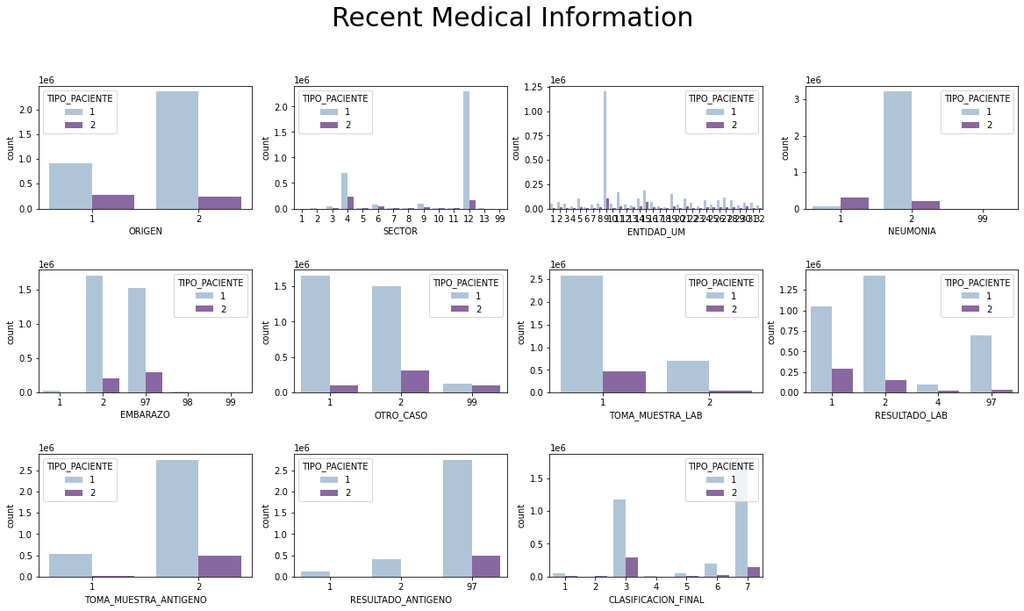

```python
features= df.loc[:, ~df.columns.isin(['FECHA_ACTUALIZACION', 'ID_REGISTRO','FECHA_INGRESO','FECHA_SINTOMAS', 'FECHA_DEF',"EDAD"])]
features = features.columns

categories = {"Clinical History":["DIABETES","EPOC","ASMA","INMUSUPR","HIPERTENSION","OTRA_COM","OBESIDAD","RENAL_CRONICA","TABAQUISMO"],"Demographics":["SEXO","ENTIDAD_NAC","MUNICIPIO_RES","EDAD","NACIONALIDAD","HABLA_LENGUA_INDIG","INDIGENA","MIGRANTE","PAIS_NACIONALIDAD","PAIS_ORIGEN","UCI"], "Recent Medical Information":["ORIGEN","SECTOR","ENTIDAD_UM","NEUMONIA","EMBARAZO","OTRO_CASO","TOMA_MUESTRA_LAB","RESULTADO_LAB","TOMA_MUESTRA_ANTIGENO","RESULTADO_ANTIGENO","CLASIFICACION_FINAL"]}

#counter for printing ylabel each row
counter = 0

#figure size
plt.figure(figsize=(20, 18))

#subplots space
plt.subplots_adjust(hspace=0.5)
plt.subplots_adjust(wspace=0.3)

#counter_length
counter_length = 0

ncols = 4
nrows = 5

#counter for plotting legend
counter_2 = 0

#legend only one time
counter_3 = 0

for key in categories:
    #main title
    plt.suptitle(key, fontsize=30, y = 0.95)

    # loop through the length of tickers and keep track of index
    for n, i in enumerate(categories[key]):

        # add a new subplot iteratively using nrows and cols
        ax = plt.subplot(nrows, ncols, n + 1)
        ax.set(xlabel=None)

        #data = data.compute()

        #scatterplot Time vs Value for each measure type
        ax = sns.countplot(data = df, x = i,hue = "TIPO_PACIENTE", palette = 'BuPu')

    plt.savefig('plot_'+str(counter_length)+'.png')

    #figure size
    plt.figure(figsize=(20, 18))

    #subplots space
    plt.subplots_adjust(hspace=0.5)
```

### Verify Data Quality

```python
df['FD<FI']=df['FECHA_DEF']<df['FECHA_INGRESO']
df['FD<FI'].value_counts()
```

```
False    3779313
True         327
Name: FD<FI, dtype: int64
```

```python
df['FD<FS']=df['FECHA_DEF']<df['FECHA_SINTOMAS']
df['FD<FS'].value_counts()
```

```
False    3779630
True          10
Name: FD<FS, dtype: int64
```

```python
df['FI<FS']=df['FECHA_INGRESO']<df['FECHA_SINTOMAS']
df['FI<FS'].value_counts()
```

```
False    3779639
True           1
Name: FI<FS, dtype: int64
```

##### Cases when dates follow an abnormal pattern, e.g., deaths' date prior to admission date.

```
[Text(0.5, 1.0, 'Age histogram (ages > 100)')]
```

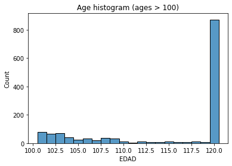

```python
#Age: feature with an abnormal high value of values=120
sns.histplot(df['EDAD'].loc[df['EDAD'] > 100], binwidth=1, discrete=True).set(title='Age histogram (ages > 100)')
```

##### Ages until 120 years old will be considered. The histogram suggests some issue by attributing 120 years old to so many patients, which will be considered in the preprocessing stage.

## 3 - Preprocessing

```python
#Cleaning 'meaningless' values according to catalog
df["MUNICIPIO_RES"].replace({999: pd.NA, 998: pd.NA, 997: pd.NA},  inplace=True)


for i in df.columns:
    if not(i in ['FECHA_ACTUALIZACION', 'ID_REGISTRO','MUNICIPIO_RES', 'FECHA_INGRESO','FECHA_SINTOMAS', 'FECHA_DEF','EDAD']):
        df[i].replace({97: pd.NA, 98: pd.NA, 99: pd.NA},  inplace=True)
```

```python
#Cleaning age feature since it has an abnormal high value of values=120

#df['EDAD'].mask(df['EDAD'] == 120, pd.NA, inplace=True)

#_____ Instead of NA if we want to substitute  for the mean
mean_age=df['EDAD'].mean()
df['EDAD'].mask(df['EDAD'] == 120, round(mean_age), inplace=True)
print("Age mean: ", mean_age)
#sns.histplot(df['EDAD'], binwidth=1, discrete=True)
```

```
Age mean:  41.283576213607645
```

##### Creation of variable for cases where patients died (Fecha_DEF not null)

```python
df["DEAD"]=np.where(df["FECHA_DEF"].isnull(),pd.NA,1)
```

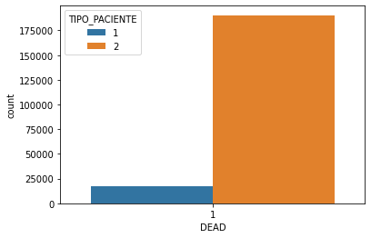

```python
sns.countplot(data=df, x = "DEAD",hue = "TIPO_PACIENTE")
```

##### As one may observe in the figure above, there are some patients classified as a Positive outcome (Tipo Paciente) that have died.

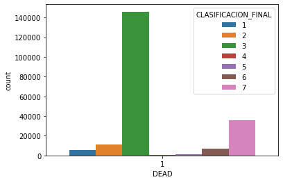

```python
sns.countplot(data=df, x = "DEAD",hue = "CLASIFICACION_FINAL")
```

##### Distribution of people who died accordingly to their Clasificacion Final.

```python
for i in df.columns:
    if not(i in ['FECHA_ACTUALIZACION', 'ID_REGISTRO', 'FECHA_INGRESO','FECHA_SINTOMAS', 'FECHA_DEF','EDAD']):
        df[i] = df[i].astype('category')

df["EDAD"] = df["EDAD"].astype('int')
```

```python
df.info(show_counts=True)
```

```
<class 'pandas.core.frame.DataFrame'>
Int64Index: 3779640 entries, 1 to 3779640
Data columns (total 44 columns):
 #   Column                 Non-Null Count    Dtype
---  ------                 --------------    -----
 0   FECHA_ACTUALIZACION    3779640 non-null  object
 1   ID_REGISTRO            3779640 non-null  object
 2   ORIGEN                 3779640 non-null  category
 3   SECTOR                 3779630 non-null  category
 4   ENTIDAD_UM             3779640 non-null  category
 5   SEXO                   3779640 non-null  category
 6   ENTIDAD_NAC            3762097 non-null  category
 7   ENTIDAD_RES            3779640 non-null  category
 8   MUNICIPIO_RES          3779603 non-null  category
 9   TIPO_PACIENTE          3779640 non-null  category
```

[output cut: 36 more lines]

### Logistic Regression

```python
x = df.loc[:, ~df.columns.isin(["CLASIFICACION_FINAL", 'FECHA_ACTUALIZACION', 'ID_REGISTRO','FECHA_INGRESO','FECHA_SINTOMAS', 'FECHA_DEF',"TIPO_PACIENTE","UCI","INTUBADO","NEUMONIA",'FD<FI', 'FD<FS','FI<FS','DEAD','OTRO_CASO','TOMA_MUESTRA_LAB','RESULTADO_LAB','TOMA_MUESTRA_ANTIGENO','RESULTADO_ANTIGENO'])]
y = df["TIPO_PACIENTE"]
```

```python
#one-hot encoder
x = x.select_dtypes(exclude=['number']) \
                .apply(LabelEncoder().fit_transform) \
                .join(x.select_dtypes(include=['number']))
```

```python
#70%/15%/15% training/testing/validation
X_train, X_test, y_train, y_test = train_test_split(x.values, y.values, test_size=0.3, random_state=42)
X_test, X_val, y_test, y_val = train_test_split(X_test, y_test, test_size=0.5, random_state=42)
```

```python
lr = LogisticRegression(solver = 'newton-cg')
```

```python
lr.fit(X_train, y_train)
```

```
LogisticRegression(solver='newton-cg')
```

```python
importance = lr.coef_[0]
```

```python
importance
```

```
array([-9.16894138e-01, -1.58518129e-01, -3.40800834e-02,  1.97829921e+00,
        3.97053851e-03,  3.32894256e-02,  3.50497416e-03, -4.53379060e-01,
       -1.43827262e+00,  1.85710312e-02, -2.69414539e-01, -7.07532500e-01,
       -3.49648932e-01,  4.50426843e-01, -7.75478978e-01, -2.78530681e-01,
       -4.25076734e-01, -2.19434615e-01, -2.73534186e-01, -1.02818106e+00,
        2.14087227e-01, -2.11540571e-01, -9.19657133e-04,  2.14211363e-03,
        4.72943298e-02])
```

```python
from operator import itemgetter
indices, importance_sorted = zip(*sorted(enumerate(importance), key=itemgetter(1)))
```

```python
x.columns
```

```
Index(['ORIGEN', 'SECTOR', 'ENTIDAD_UM', 'SEXO', 'ENTIDAD_NAC', 'ENTIDAD_RES',
       'MUNICIPIO_RES', 'NACIONALIDAD', 'EMBARAZO', 'HABLA_LENGUA_INDIG',
       'INDIGENA', 'DIABETES', 'EPOC', 'ASMA', 'INMUSUPR', 'HIPERTENSION',
       'OTRA_COM', 'CARDIOVASCULAR', 'OBESIDAD', 'RENAL_CRONICA', 'TABAQUISMO',
       'MIGRANTE', 'PAIS_NACIONALIDAD', 'PAIS_ORIGEN', 'EDAD'],
      dtype='object')
```

```python
importance
```

```
array([-9.16894138e-01, -1.58518129e-01, -3.40800834e-02,  1.97829921e+00,
        3.97053851e-03,  3.32894256e-02,  3.50497416e-03, -4.53379060e-01,
       -1.43827262e+00,  1.85710312e-02, -2.69414539e-01, -7.07532500e-01,
       -3.49648932e-01,  4.50426843e-01, -7.75478978e-01, -2.78530681e-01,
       -4.25076734e-01, -2.19434615e-01, -2.73534186e-01, -1.02818106e+00,
        2.14087227e-01, -2.11540571e-01, -9.19657133e-04,  2.14211363e-03,
        4.72943298e-02])
```

```
Feature: 0, Score: -0.91689
Feature: 1, Score: -0.15852
Feature: 2, Score: -0.03408
Feature: 3, Score: 1.97830
Feature: 4, Score: 0.00397
Feature: 5, Score: 0.03329
Feature: 6, Score: 0.00350
Feature: 7, Score: -0.45338
Feature: 8, Score: -1.43827
Feature: 9, Score: 0.01857
Feature: 10, Score: -0.26941
Feature: 11, Score: -0.70753
Feature: 12, Score: -0.34965
Feature: 13, Score: 0.45043
Feature: 14, Score: -0.77548
Feature: 15, Score: -0.27853
Feature: 16, Score: -0.42508
Feature: 17, Score: -0.21943
Feature: 18, Score: -0.27353
Feature: 19, Score: -1.02818
Feature: 20, Score: 0.21409
Feature: 21, Score: -0.21154
Feature: 22, Score: -0.00092
Feature: 23, Score: 0.00214
Feature: 24, Score: 0.04729
```

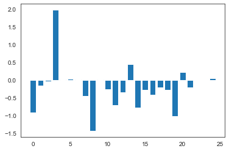

```python
# summarize feature importance
sns.set_style(style='white')

new = {"i":[], "v":[]}
for i, v in enumerate(importance):
    new["i"].append(i)
    new["v"].append(v)
    print('Feature: %0d, Score: %.5f' % (i, v))

# plot feature importance
plt.bar([x for x in range(len(importance))], importance)
plt.grid(False)
plt.show()
```

```python
new = pd.DataFrame(new)
new["abs"] = abs(new.v)
new = new.sort_values(by=['abs'],ascending=True)
new
```

|  | i | v | abs |
| --- | --- | --- | --- |
| 22 | 22 | -0.000920 | 0.000920 |
| 23 | 23 | 0.002142 | 0.002142 |
| 6 | 6 | 0.003505 | 0.003505 |
| 4 | 4 | 0.003971 | 0.003971 |
| 9 | 9 | 0.018571 | 0.018571 |
| 5 | 5 | 0.033289 | 0.033289 |
| 2 | 2 | -0.034080 | 0.034080 |
| 24 | 24 | 0.047294 | 0.047294 |
| 1 | 1 | -0.158518 | 0.158518 |
| 21 | 21 | -0.211541 | 0.211541 |
| 20 | 20 | 0.214087 | 0.214087 |
| 17 | 17 | -0.219435 | 0.219435 |
| 10 | 10 | -0.269415 | 0.269415 |
| 18 | 18 | -0.273534 | 0.273534 |
| 15 | 15 | -0.278531 | 0.278531 |
| 12 | 12 | -0.349649 | 0.349649 |
| 16 | 16 | -0.425077 | 0.425077 |
| 13 | 13 | 0.450427 | 0.450427 |
| 7 | 7 | -0.453379 | 0.453379 |
| 11 | 11 | -0.707532 | 0.707532 |
| 14 | 14 | -0.775479 | 0.775479 |
| 0 | 0 | -0.916894 | 0.916894 |
| 19 | 19 | -1.028181 | 1.028181 |
| 8 | 8 | -1.438273 | 1.438273 |
| 3 | 3 | 1.978299 | 1.978299 |

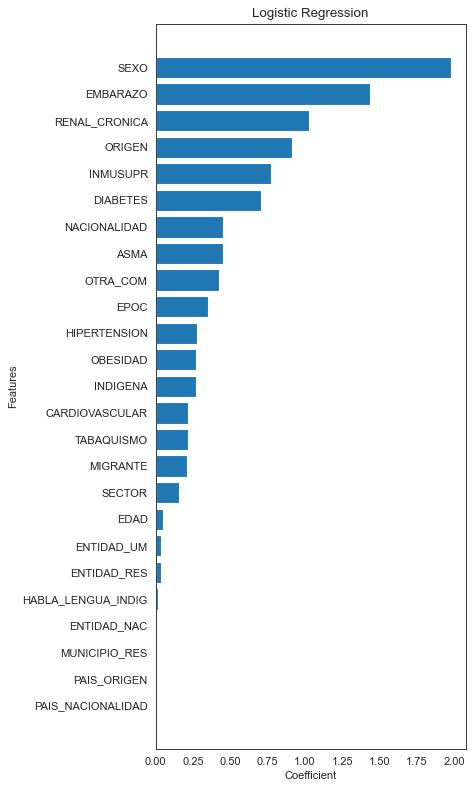

```python
new["labels"] = x.columns[new.i]
from matplotlib.pyplot import figure
figure(figsize=(5, 12), dpi=80)
plt.barh([x for x in range(len(new["abs"]))], new["abs"])
plt.ylabel("Features")
plt.xlabel("Coefficient")
plt.title("Logistic Regression")

col = [x for x in new.labels]
plt.yticks(np.arange(len(col)), col)
plt.show()
```

```python
predictions = lr.predict(X_test)
```

```python
from sklearn.metrics import classification_report
print(classification_report(y_test, predictions))
```

```
              precision    recall  f1-score   support

           1       0.90      0.98      0.94    490700
           2       0.70      0.30      0.42     76246

    accuracy                           0.89    566946
   macro avg       0.80      0.64      0.68    566946
weighted avg       0.87      0.89      0.87    566946
```

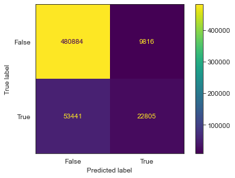

```python
confusion_matrix = metrics.confusion_matrix(y_test, predictions)

cm_display = metrics.ConfusionMatrixDisplay(confusion_matrix = confusion_matrix, display_labels = [False, True])

cm_display.plot()
plt.grid(False)
plt.show()
```

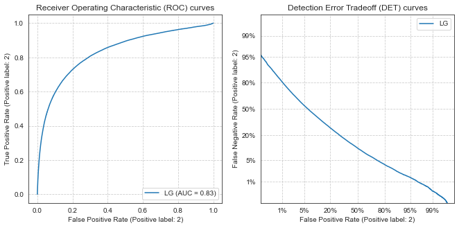

```python
# prepare plots
sns.set_style(style='white')
fig, [ax_roc, ax_det] = plt.subplots(1, 2, figsize=(11, 5))

RocCurveDisplay.from_estimator(lr, X_test, y_test, ax=ax_roc, name="LG")

DetCurveDisplay.from_estimator(lr, X_test, y_test, ax=ax_det, name="LG")

ax_roc.set_title("Receiver Operating Characteristic (ROC) curves")

ax_det.set_title("Detection Error Tradeoff (DET) curves")

ax_roc.grid(linestyle="--")
ax_det.grid(linestyle="--")

plt.legend()

plt.show()
```